# Aberdeen Children of the 1950s - Cohort’s Views on Future Research - 2021 Survey

Krzysztof Adamczyk

### 1. Introduction

Aberdeen Children of the 1950s (ACONF) Cohort’s Views on Future Research Survey was created in Google Forms, posted on Aberdeen Birth Cohorts FB page on 30 April 2021, and sent by email the following day to 741 cohort members. It included six questions - four asking the participant to rank priority (these were mandatory), one open question, and one multiple choice asking respondent to identify themselves as ACONF participant, member of the public, and/or researcher or public health professional. The survey was open for a week and received 460 responses. From 460 people, 8 identified as members of the public and not ACONF. Excluding non-ACONF members, and not taking into account the impact of FB page posting (which has a relatively small following), the response rate is 61%.

Out of 452 ACONF respondents, 4 also identified as “Researcher or public health professional”. This group provided 214 free text responses to Q5 which was not a mandatory question. The following analysis pertains to 452 self-identified ACONF cohort members only.

The survey opened with the below text.

“We’re interested to hear your views on potential new research on COVID-19 and the Aberdeen Children of the 1950s (ACONF) study. The last year has changed our lives dramatically – how we work, connect with family and friends, look after our health and go about our daily lives. As researchers, we are keen to understand how the changes brought about by the pandemic have affected lives of the study participants. We would value your opinion on how to prioritise these research questions and would also like to hear your thoughts on any topics you feel are important.”

### 2. Answers to Questions 1-4 (n = 452)

“We are interested in a number of topics, please tell us whether you think these are of high or low priority to research:”

**Q1. “Understanding why some people are less likely to take up the COVID-19 vaccine (1 - Low priority, 5 - High priority)”**

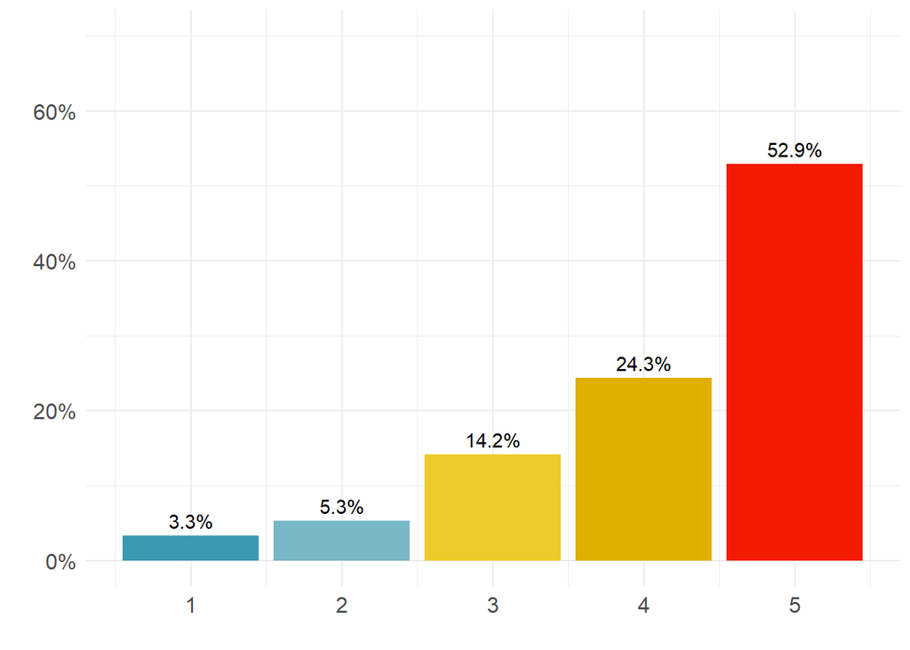

**Q2. “Understanding the experience of using the internet for daily activities (e.g. shopping, keeping in contact with friends and family) (1 - Low priority, 5 - High priority)”**

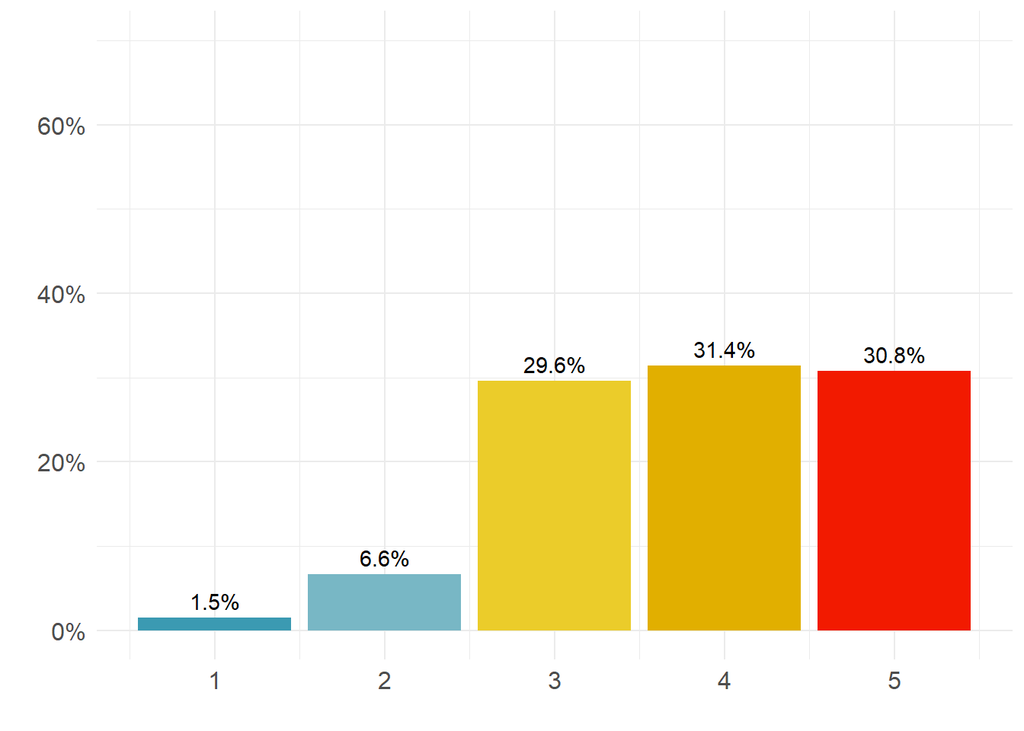

**Q3. “Examining impact of the pandemic on mental health, loneliness and wellbeing (1 - Low priority, 5 - High priority)”**

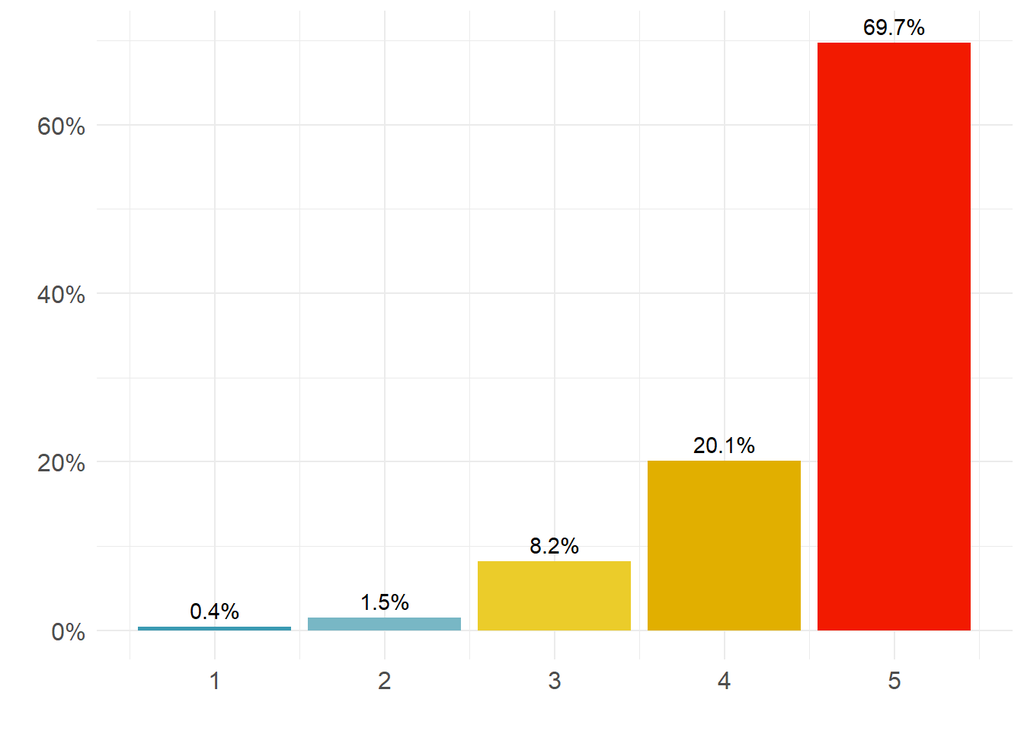

**Q4. Understanding how experience as a child of the 50s and 60s has helped with coping with the effects of COVID-19 lockdowns, social isolation and mental health issues? (1 - Low priority, 5 - High priority)"**

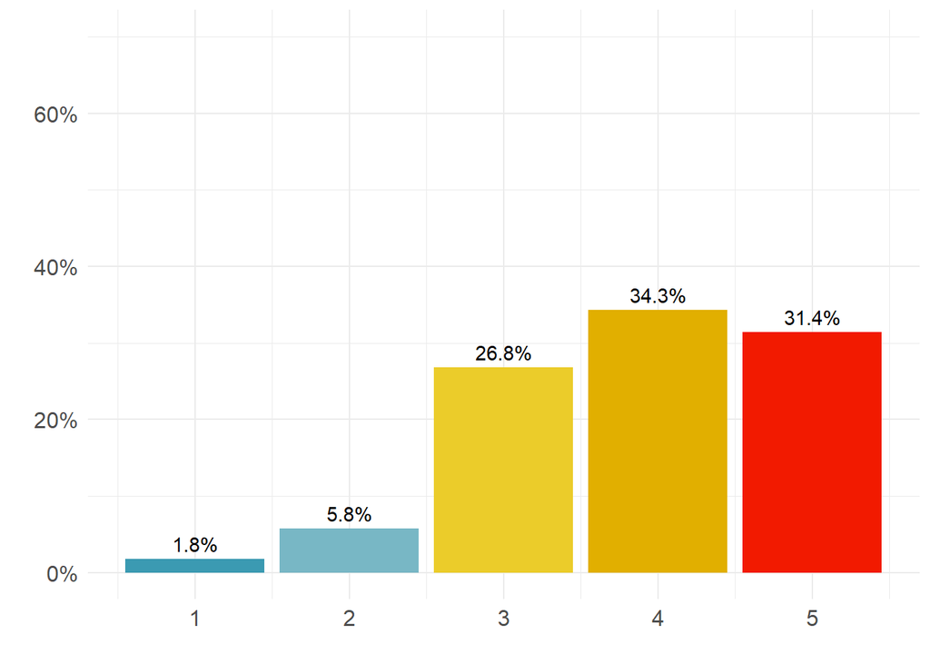

### 3. Answers to Question 5 (n = 214)

Respondents were asked: **“Are there any other aspects of life during the pandemic that you think should be researched?”**

Here I calculate word frequency in all responses. This reflects the frequency of each word and not instances of responses with each word. Misspelled instances of ‘Aberdeen’ and non/hyphenated versions of ‘wellbeing’ are identified and made uniform using regex.

```r
LongAnswer <- ACONF_Views_Survey %>%
  filter(Category != "Member of the public") %>%
  filter(!is.na(FreeText)) %>%
  select(FreeText)

LongAnswer_clean <- LongAnswer %>%
  mutate(FreeText = gsub("(?i)well(.|)being", "wellbeing", FreeText)) %>%
  mutate(FreeText = gsub("(?i)Aberd\\w*", "Aberdeen", FreeText))

wordcounts <- LongAnswer_clean %>%
  unnest_tokens(word, FreeText) %>%
  anti_join(stop_words) %>%
  dplyr::count(word) %>%
  arrange(desc(n))

Themes <- LongAnswer_clean %>%
  mutate(typhoid = str_detect(FreeText, "(?i)typhoid")) %>%
  mutate(finances = str_detect(FreeText, c("(?i)finan\\w*|(?i)\\bearnings"))) %>%
  mutate(physical = str_detect(FreeText, c("(?i)physical|(?i)fitness|(?i)exercise"))) %>%
  mutate(access = str_detect(FreeText, "(?i)access|(?i)gp.*|(?i)medical")) %>%
  mutate(vaccine = str_detect(FreeText, "(?i)vaccin\\w*")) %>%
  mutate(urbanrural = str_detect(FreeText, "(?i)urban|(?i)rural")) %>%
  mutate(travel = str_detect(FreeText, "(?i)abroad|(?i)travel\\w*")) %>%
  mutate(shopping = str_detect(FreeText, "(?i)shopping")) %>%
  mutate(positives = str_detect(FreeText, "(?i)positive\\w*")) %>%
  mutate(bereavement = str_detect(FreeText, "(?i)bereavement|loss.of.close|losing.a.family|loss.of.loved.ones")) %>%
  mutate(isolation = str_detect(FreeText, ("(?i)mental.health|isolation|contact")))

DT::datatable(wordcounts, colnames = c("", "Word", "Frequency"), options = list(autoWidth = TRUE, columnDefs = list(list(width = '50px', targets = 1))))
```

|  | Word | Frequency |
| --- | --- | --- |
| 1 | people | 52 |
| 2 | health | 38 |
| 3 | pandemic | 33 |
| 4 | covid | 27 |
| 5 | impact | 25 |
| 6 | mental | 19 |
| 7 | children | 18 |
| 8 | effects | 17 |
| 9 | family | 16 |
| 10 | lockdown | 16 |

[output cut: 797 more lines]

#### 3.1 Free text respones and selected themes

In this section, free text responses can be searched and viewed in the tab ‘All responses’. In other tabs, a selection of themes is identified and grouped so relevant responses can be read together. In all theme groupings for word variations and multiple words regex is used.

For example, ‘Finances’ includes ‘financial’ (4), ‘finances’ (1), and ‘financially’ (1), as well as ‘earnings’ (3). No instances of ‘money’ or ‘economical’ or their variations are found. These are not broken down by number for each grouping at the moment.

Some frequent words such as ‘people’ (52) are very non-specific, while themes such as access to healthcare need more key words such as ‘access’, ‘GP’, ‘services’, ‘medical’ and still leave an unrelated cases which is manually excluded.

Code used for rexeg can be viewed by exandind chunk in the previous section.

##### **All responses**

|  | All responses |
| --- | --- |
| 1 | What positives resulted from the pandemic |
| 2 | Family cohesion; changing diets |
| 3 | Compare urban and rural dwellers, re; mental health and wellbeing. |
| 4 | Social isolation and effects on mental health, especially those living alone. I have found it very difficult, especially this lockdown. |
| 5 | How the regular change in levels and restrictions in themselves can be confusing and disrupt routine. |
| 6 | All aspects of society have been receiving financial help except folk who worked all their lives and do not qualify for benefits of any kind, the folk who have paid and supported the welfare state. Th… |
| 7 | Looking forward from lockdown to freedom and the effect this has on our outlook for the future - trepidation or elation? |
| 8 | Mental health and isolation |
| 9 | Any long term effect on children, toddler etc |
| 10 | Missing family |

[output cut: 204 more lines]

##### Typhoid

|  | Typhoid |
| --- | --- |
| 1 | Any lessons learned from the typhoid epidemic in Aberdeen in the 60s? |
| 2 | Most off the children of the fifties would have been affected by the typhoid outbreak in Aberdeen and would have been isolated at home during the outbreak, What are the differences in isolation ? |
| 3 | As children, in 1964, we lived through a different public health emergency ( the typhoid epidemic): different from the current pandemic, in terms of in terms of scale and severity. Nevertheless, valua… |
| 4 | Comparison with how people behaved during typhoid outbreak |
| 5 | Did the experience of the typhoid epidemic in Aberdeen help you get through this in any way. eg hygiene |
| 6 | The impact of pandemic on families of children of 50s and were children of 50s able to support eg financially grannysitters emotional supports Children of the 50s experienced a short shutdown and long… |
| 7 | As children of the 50s 60s some may have recall of the typhoid holidays, as I recall them. Dr M Queen? Hygiene with your school milk. Aberdeen isolated and in quarantine? Community solidarity. |
| 8 | Recollections and lessons learned from the Aberdeen typhoid epidemic |
| 9 | I recalled with some clarity, the Typhoid outbreak in Aberdeen , and to a degree remembered the impact. In some ways it helped , as some of the restrictions were not entirely new. I also wander how ma… |

##### Finances

|  | Finances / Earnings |
| --- | --- |
| 1 | All aspects of society have been receiving financial help except folk who worked all their lives and do not qualify for benefits of any kind, the folk who have paid and supported the welfare state. Th… |
| 2 | Understanding impact of pandemic on financial wellbeing and how this impacts mental health. |
| 3 | Examining the impact on family finances and for future generations. |
| 4 | The impact of pandemic on families of children of 50s and were children of 50s able to support eg financially grannysitters emotional supports Children of the 50s experienced a short shutdown and long… |
| 5 | Financial and other help for those in poverty required to self isolate and live |
| 6 | Loss of earnings |
| 7 | Loss of earnings |
| 8 | Loss of earnings |
| 9 | financial impact. |

##### Healthcare access

|  | Access / GP / Services / Medical |
| --- | --- |
| 1 | Medical treatment delays |
| 2 | How have child of the 50s and 60s embraced using the Internet for medical needs, shopping needs and activities other than for daily activities other than social needs (eg. using Amazon &amp; Ebay wher… |
| 3 | Overall effect of being unable to access proper GP visits |
| 4 | 1. Greater involvement of GP who should know their patients needs. 2. Understanding of people’s willingness to create or believe false information about about vaccination/COVID 19. Hope this helps. |
| 5 | How other illnesses contacted impacted on health and wellbeing and access to services. |
| 6 | 1. Whether aspects such as internet banking, internet shopping, payment by card in shops and less cash in circulation generally have been forced on people by necessity but will be used going forward b… |
| 7 | I see you are focusing on the psychological and mental wellbeing consequences of the pandemic but I think you need to also consider general health, physical wellbeing and physical fitness consequences… |
| 8 | Understanding the different medical effects of COVID through different age groups . |
| 9 | How it has changed the "older generation" into shopping online, a cashless environment, socialising online, Dr contact online and the benefits derived elsewhere from an increased IT awareness for info… |
| 10 | Access to GPs (face to face) |

[output cut: 6 more lines]

##### Physical health

|  | Physical / Fitness / Exercise |
| --- | --- |
| 1 | Obesity, physical health through lack of exercise, people sitting in front of a pc all day every day without leaving home and the effects on their health. |
| 2 | Physical health &amp; fitness |
| 3 | Exercise and weight gain |
| 4 | Perhaps levels of fitness and activity ... better / worse. |
| 5 | Dietary effects and exercise |
| 6 | Physical health and fitness . Health - check ups , interventions, appointments, ops - delays |
| 7 | I see you are focusing on the psychological and mental wellbeing consequences of the pandemic but I think you need to also consider general health, physical wellbeing and physical fitness consequences… |
| 8 | Physical wellbeing during lockdown, ie fitness and diet. Have we become sloths? |
| 9 | Using alcohol to self medicate with regards to mental health and eating and exercise patterns relating to lockdown |
| 10 | How the Children of the 50s generation growing up as LGBT, when homosexuality was illegal till 1977 in Scotland, has impacted on our physical, social and mental wellbeing. |

[output cut: 5 more lines]

##### Vaccine

|  | Vaccine |
| --- | --- |
| 1 | Try and avoid negativity in the media re vaccines as this has worried many people. If reaction to vaccine is very minimal then information should be kept out of the media |
| 2 | 1. Greater involvement of GP who should know their patients needs. 2. Understanding of people’s willingness to create or believe false information about about vaccination/COVID 19. Hope this helps. |
| 3 | I think you are skirting around difficult questions which are multidimensional, so I think you should survey a relevant population segment (vaccine refusers, people suffering drop in mental wellbeing … |
| 4 | Do the cohort watch, listen to or read the news and how does that affect mental health, having the vaccine and internet use. |
| 5 | How travelling abroad will be affected because countries are not vaccinating there population like what is being done in UK. Would we be able to carry different strains of covid back to UK from abroad… |
| 6 | Underlying health issues of people and how this relates to the impact of covid and the effectiveness of the vaccine. |
| 7 | The fact that the NHS availability for other illnesses did not seem to exist. There was no continuity with GPs. The worry about side effects of vaccines and it's contents . |

##### Urban/rural

|  | Urban / Rural |
| --- | --- |
| 1 | Compare urban and rural dwellers, re; mental health and wellbeing. |
| 2 | Why has behaviour when allowed out, in both urban and rural areas, been so selfish? littering, disrespect for places other people live, crowding etc Especially littering! |
| 3 | How location - rural/urban, close or not to other family members - has affected people of all ages |
| 4 | having been brought up in a rural environment I have always felt a robust approach to this pandemic but always respecting social distancing and others measures as recommended and this seems to have wo… |
| 5 | The impact of mental health and wellbeing of of individuals relative to the environment that people live within eg rural , semi urban and city/ town centre. |

##### Travel

|  | Travel / Abroad |
| --- | --- |
| 1 | The knock on effect of coming out of lockdown and facing the world; going out and meeting people once again. I for one am finding this difficult to go into my local supermarket or to travel into town … |
| 2 | The lack of understanding about the seriousness of the situation, for example, the obsession about going abroad on holiday, or spending time indoors at Christmas. Even now, I know that people who norm… |
| 3 | How inability to travel to visit family overseas has adversely affected wellbeing |
| 4 | The apparent imperative to holiday abroad. The role of the media, especially the BBC, in spreading Covid disinfornation and undermining UK and Scot Gov public health messaging. |
| 5 | The impact on future plans to travel abroad. |
| 6 | How travelling abroad will be affected because countries are not vaccinating there population like what is being done in UK. Would we be able to carry different strains of covid back to UK from abroad… |
| 7 | How the experience of the Pandemic has changed the way you will live and behave going forward e.g shopping, travelling, the way we greet each other, eating and drinking at home. |

##### Shopping

|  | Shopping |
| --- | --- |
| 1 | How have child of the 50s and 60s embraced using the Internet for medical needs, shopping needs and activities other than for daily activities other than social needs (eg. using Amazon &amp; Ebay wher… |
| 2 | 1. Whether aspects such as internet banking, internet shopping, payment by card in shops and less cash in circulation generally have been forced on people by necessity but will be used going forward b… |
| 3 | How it has changed the "older generation" into shopping online, a cashless environment, socialising online, Dr contact online and the benefits derived elsewhere from an increased IT awareness for info… |
| 4 | How the experience of the Pandemic has changed the way you will live and behave going forward e.g shopping, travelling, the way we greet each other, eating and drinking at home. |

##### Positives

|  | Positives |
| --- | --- |
| 1 | What positives resulted from the pandemic |
| 2 | While never wishing to forget the devastating effect the pandemic has had on so many people perhaps also looking at the more positive impacts on life - eg the willingness to help others, looking out f… |

##### Bereavement

|  | Bereavement / Loss |
| --- | --- |
| 1 | Impact of losing a family member to Covid 19 |
| 2 | Effect of bereavement (non covid) during pandemic. |
| 3 | coping with bereavement |
| 4 | Effects of isolation on people who live on their own; people with disability. Has the pandemic brought neighbourhoods closer together ? Has the loss of loved ones been especially traumatic. Have peopl… |
| 5 | Dealing with the loss of close relatives to Covid. |

##### Mental health

|  | Mental health / Isolation / Contact |
| --- | --- |
| 1 | Compare urban and rural dwellers, re; mental health and wellbeing. |
| 2 | Social isolation and effects on mental health, especially those living alone. I have found it very difficult, especially this lockdown. |
| 3 | Mental health and isolation |
| 4 | How gardening and walking helped maintain peoples sanity. How not using the internet was a boost to mental health. |
| 5 | Isolation should be included. You may not be lonely if everyone is contacting you but still feel isolated from all the activities you normally undertook. |
| 6 | Understanding impact of pandemic on financial wellbeing and how this impacts mental health. |
| 7 | Isolation |
| 8 | Mental health / coping strategies |
| 9 | The pandemic has incurred a great deal of “collateral damage” especially among older age groups. Lack of availability of care, fewer domiciliary visits by health professionals and the unseen plight of… |
| 10 | Do the cohort watch, listen to or read the news and how does that affect mental health, having the vaccine and internet use. |

[output cut: 13 more lines]